# Unreliability example for paired-samples $t$-test

Author

Phil Chalmers

This basic example demonstrates the influence of unreliable measurements has on the empirical power to reject a null hypothesis of no effect for paired-sample $t$-test applications. Four reliability ratios (`rxx`) are investigated alongside four sample sizes (50, 100, 200, 400). Three non-zero effect sizes are included using Cohen’s d to evaluate the empirical power.

# Simulation code

```r
library(SimDesign)

Design <- createDesign(rxx=c(1, .8, .6, .4),
                       N = c(50, 100, 200, 400),
                       dT = c(0, .2, .5, .8)) # difference in true-scores

# (Optional) get the Rstudio IDE flags to avoid false positives in the source code
Attach(Design, RStudio_flags = TRUE)
```

```
# !diagnostics suppress=rxx,N,dT
```

```r
# !diagnostics suppress=rxx,N,dT
```

Scratch algebra notes for obtaining $VAR(E) = \sigma^2_E$ given $r_{xx}$ and $VAR(T)= \sigma^2_T$.

$$r_{xx} = \frac{VAR(T)}{VAR(X)} = \frac{VAR(T)}{VAR(T) + VAR(E)} = \frac{\sigma^2_T}{\sigma^2_T + \sigma^2_E}$$
$$r_{xx} (\sigma^2_T + \sigma^2_E) = \sigma^2_T$$
$$r_{xx} \sigma^2_T + r_{xx}\sigma^2_E = \sigma^2_T$$
$$r_{xx} \sigma^2_E = \sigma^2_T - r_{xx}\sigma^2_T$$
$$\sigma^2_E = \sigma^2_T/r_{xx} - \sigma^2_T$$
$$\sigma^2_E = \sigma^2_T (1/r_{xx} - 1)$$
$$\sigma^2_E = \sigma^2_T \left(\frac{1 - r_{xx}}{r_{xx}}\right)$$

```r
Generate <- function(condition, fixed_objects = NULL) {
    Attach(condition)
    group <- gl(2, N, labels = c('pre', 'post'))
    true.scores <- c(rnorm(N, mean=dT), rnorm(N))
    # E(T) = E(mu_i)
    mu.t <- (0 + dT)/2
    # VAR(T) = E(var_i) + mu^2 = E(s_i^2 + mu_i^2) + mu^2
    var.t <- .5 * (1^2 + 0^2) + .5 * (1^2 + dT^2) - mu.t^2
    var.e <- var.t * ((1 - rxx) / rxx)
    X <- true.scores + rnorm(N*2, sd=sqrt(var.e))
    dat <- data.frame(pre=X[group == 'pre'],
                      post=X[group == 'post'])
    dat
}

Analyse <- function(condition, dat, fixed_objects = NULL) {
    out <- with(dat, t.test(pre, post, paired=TRUE))
    # return p-value, mean difference, and SE
    nc(p=out$p.value, mean_diff=out$estimate, SE=out$stderr)
}

Summarise <- function(condition, results, fixed_objects = NULL) {
    power <- EDR(results[,"p"])
    means <- colMeans(subset(results, select=mean_diff:SE))
    c(power=power, means)
}
```

```r
res <- runSimulation(design=Design, replications=5000, generate=Generate,
                     analyse=Analyse, summarise=Summarise, parallel=TRUE)
res
```

```
# A tibble: 64 × 10
     rxx     N    dT  power   mean_diff       SE REPLICATIONS SIM_TIME      SEED
   <dbl> <dbl> <dbl>  <dbl>       <dbl>    <dbl>        <dbl> <chr>        <int>
 1   1      50     0 0.0554 -0.00086747 0.19893          5000 0.19s     3.5437e8
 2   0.8    50     0 0.0506  0.0029264  0.22232          5000 0.26s     1.5165e9
 3   0.6    50     0 0.0402 -0.0031533  0.25670          5000 0.21s     2.0015e9
 4   0.4    50     0 0.044  -0.00084730 0.31483          5000 0.20s     4.5734e8
 5   1     100     0 0.053  -0.0013948  0.14087          5000 0.23s     1.0642e8
 6   0.8   100     0 0.0464  0.00042688 0.15769          5000 0.21s     8.9462e8
 7   0.6   100     0 0.052  -0.0019927  0.18206          5000 0.31s     9.3027e8
 8   0.4   100     0 0.0468 -0.00047488 0.22305          5000 0.41s     8.5896e8
 9   1     200     0 0.049  -0.0018811  0.099787         5000 0.42s     1.5194e9
10   0.8   200     0 0.048   0.0027181  0.11179          5000 0.39s     1.5774e8
# ℹ 54 more rows
# ℹ 1 more variable: COMPLETED <chr>
```

# Results

Below is summary information in the form of tables and plots to demonstrate the negative effect of unreliability.

```r
library(dplyr)
res |> select(rxx:SE, -power) |>
    mutate(bias=dT-mean_diff) |>
    arrange(N, dT, rxx) |>
    select(-mean_diff) |> knitr::kable()
```

| rxx | N | dT | SE | bias |
| --- | --- | --- | --- | --- |
| 0.4 | 50 | 0.0 | 0.315 | 0.001 |
| 0.6 | 50 | 0.0 | 0.257 | 0.003 |
| 0.8 | 50 | 0.0 | 0.222 | -0.003 |
| 1.0 | 50 | 0.0 | 0.199 | 0.001 |
| 0.4 | 50 | 0.2 | 0.315 | 0.002 |
| 0.6 | 50 | 0.2 | 0.258 | 0.002 |
| 0.8 | 50 | 0.2 | 0.222 | -0.002 |
| 1.0 | 50 | 0.2 | 0.199 | 0.007 |
| 0.4 | 50 | 0.5 | 0.320 | 0.002 |
| 0.6 | 50 | 0.5 | 0.260 | -0.007 |
| 0.8 | 50 | 0.5 | 0.224 | 0.002 |
| 1.0 | 50 | 0.5 | 0.198 | -0.001 |
| 0.4 | 50 | 0.8 | 0.329 | -0.005 |
| 0.6 | 50 | 0.8 | 0.265 | -0.005 |
| 0.8 | 50 | 0.8 | 0.226 | 0.003 |
| 1.0 | 50 | 0.8 | 0.199 | -0.002 |
| 0.4 | 100 | 0.0 | 0.223 | 0.000 |
| 0.6 | 100 | 0.0 | 0.182 | 0.002 |
| 0.8 | 100 | 0.0 | 0.158 | 0.000 |
| 1.0 | 100 | 0.0 | 0.141 | 0.001 |
| 0.4 | 100 | 0.2 | 0.223 | 0.002 |
| 0.6 | 100 | 0.2 | 0.182 | 0.001 |
| 0.8 | 100 | 0.2 | 0.158 | -0.002 |
| 1.0 | 100 | 0.2 | 0.141 | -0.003 |
| 0.4 | 100 | 0.5 | 0.227 | 0.004 |
| 0.6 | 100 | 0.5 | 0.184 | 0.002 |
| 0.8 | 100 | 0.5 | 0.158 | -0.003 |
| 1.0 | 100 | 0.5 | 0.141 | 0.002 |
| 0.4 | 100 | 0.8 | 0.234 | 0.005 |
| 0.6 | 100 | 0.8 | 0.188 | 0.000 |
| 0.8 | 100 | 0.8 | 0.160 | -0.001 |
| 1.0 | 100 | 0.8 | 0.141 | -0.001 |
| 0.4 | 200 | 0.0 | 0.158 | -0.001 |
| 0.6 | 200 | 0.0 | 0.129 | -0.004 |
| 0.8 | 200 | 0.0 | 0.112 | -0.003 |
| 1.0 | 200 | 0.0 | 0.100 | 0.002 |
| 0.4 | 200 | 0.2 | 0.158 | -0.003 |
| 0.6 | 200 | 0.2 | 0.129 | 0.001 |
| 0.8 | 200 | 0.2 | 0.112 | -0.001 |
| 1.0 | 200 | 0.2 | 0.100 | 0.000 |
| 0.4 | 200 | 0.5 | 0.161 | 0.003 |
| 0.6 | 200 | 0.5 | 0.131 | 0.000 |
| 0.8 | 200 | 0.5 | 0.112 | 0.000 |
| 1.0 | 200 | 0.5 | 0.100 | 0.000 |
| 0.4 | 200 | 0.8 | 0.165 | 0.000 |
| 0.6 | 200 | 0.8 | 0.133 | 0.001 |
| 0.8 | 200 | 0.8 | 0.114 | -0.001 |
| 1.0 | 200 | 0.8 | 0.100 | 0.001 |
| 0.4 | 400 | 0.0 | 0.112 | -0.001 |
| 0.6 | 400 | 0.0 | 0.091 | 0.000 |
| 0.8 | 400 | 0.0 | 0.079 | -0.001 |
| 1.0 | 400 | 0.0 | 0.071 | 0.000 |
| 0.4 | 400 | 0.2 | 0.112 | 0.001 |
| 0.6 | 400 | 0.2 | 0.091 | -0.001 |
| 0.8 | 400 | 0.2 | 0.079 | -0.001 |
| 1.0 | 400 | 0.2 | 0.071 | 0.000 |
| 0.4 | 400 | 0.5 | 0.114 | -0.002 |
| 0.6 | 400 | 0.5 | 0.092 | 0.002 |
| 0.8 | 400 | 0.5 | 0.080 | 0.000 |
| 1.0 | 400 | 0.5 | 0.071 | 0.000 |
| 0.4 | 400 | 0.8 | 0.117 | -0.002 |
| 0.6 | 400 | 0.8 | 0.094 | 0.000 |
| 0.8 | 400 | 0.8 | 0.080 | 0.001 |
| 1.0 | 400 | 0.8 | 0.071 | 0.000 |

Kind of verbose. Here’s a better depiction, averaging over the sample sizes.

```r
library(dplyr)
res |> select(rxx:SE, -power) |>
    mutate(bias=dT-mean_diff) |>
    arrange(N, dT, rxx) |>
    select(-mean_diff) |>
    group_by(rxx, dT) |> summarise(mean.SE=mean(SE)) |>
    knitr::kable()
```

```
`summarise()` has regrouped the output.
ℹ Summaries were computed grouped by rxx and dT.
ℹ Output is grouped by rxx.
ℹ Use `summarise(.groups = "drop_last")` to silence this message.
ℹ Use `summarise(.by = c(rxx, dT))` for per-operation grouping
  (`?dplyr::dplyr_by`) instead.
```

| rxx | dT | mean.SE |
| --- | --- | --- |
| 0.4 | 0.0 | 0.202 |
| 0.4 | 0.2 | 0.202 |
| 0.4 | 0.5 | 0.205 |
| 0.4 | 0.8 | 0.211 |
| 0.6 | 0.0 | 0.165 |
| 0.6 | 0.2 | 0.165 |
| 0.6 | 0.5 | 0.167 |
| 0.6 | 0.8 | 0.170 |
| 0.8 | 0.0 | 0.143 |
| 0.8 | 0.2 | 0.143 |
| 0.8 | 0.5 | 0.144 |
| 0.8 | 0.8 | 0.145 |
| 1.0 | 0.0 | 0.128 |
| 1.0 | 0.2 | 0.128 |
| 1.0 | 0.5 | 0.127 |
| 1.0 | 0.8 | 0.128 |

Estimates of the mean differences reflect the true difference between the pre-post observations regardless of the reliability (unbiased), however the associated SE is systematically larger for more unreliable instruments. This is because the within-subject variability is larger as now it is a function of individual differences variance *plus* the variance of the measurement error. This has direct implications on power to reject the null hypothesis of no difference between the pre-post tests, as demonstrated below.

For the paired samples $t$-test:

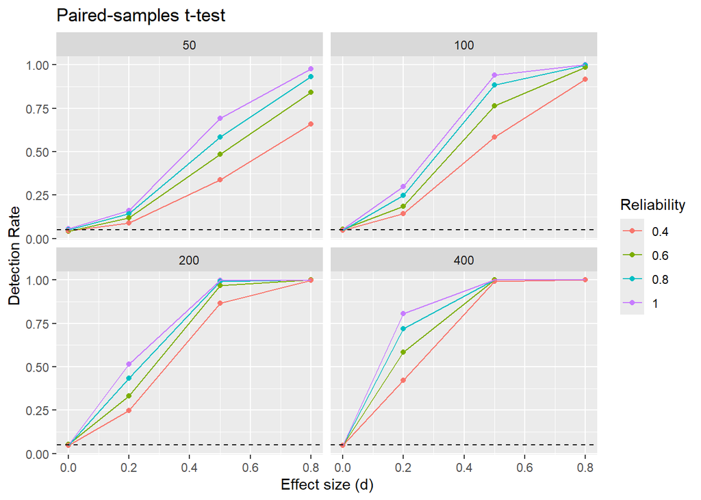

```r
library(ggplot2)
ggplot(res, aes(dT, power, colour=factor(rxx))) +
    geom_point() + geom_line() +
    geom_abline(slope = 0, intercept = .05, linetype = 'dashed') +
    xlab('Effect size (d)') + ylab('Detection Rate') + ggtitle('Empirical Power Curves') +
    scale_color_discrete('Reliability') + facet_wrap(~N) +
    ggtitle('Paired-samples t-test')
```

# Solving sample size given reliability

Alternatively, one can try to estimate the required sample size to achieve a specific power of interest (e.g., $1-\beta=.80$) for more direct comparisons. This can be achieved using the `SimSolve()` function in `SimDeisgn`, or by the related package **Spower** which will use `SimSolve()` for solving stochastic root problems in the context of power analyses. Below is an example of the former.

```r
DesignNA <- createDesign(rxx=c(1, .8, .6, .4),
                         N = NA,
                         dT = c(.2, .5, .8)) # difference in true-scores
DesignNA
```

```
# A tibble: 12 × 3
     rxx     N    dT
   <dbl> <dbl> <dbl>
 1   1      NA   0.2
 2   0.8    NA   0.2
 3   0.6    NA   0.2
 4   0.4    NA   0.2
 5   1      NA   0.5
 6   0.8    NA   0.5
 7   0.6    NA   0.5
 8   0.4    NA   0.5
 9   1      NA   0.8
10   0.8    NA   0.8
11   0.6    NA   0.8
12   0.4    NA   0.8
```

```r
solved <- SimSolve(design=DesignNA, b=.80, interval=c(3, 1000),
                   generate=Generate, analyse=Analyse, summarise=Summarise,
                   verbose=FALSE)
solved
```

```
# A tibble: 12 × 3
     rxx     N    dT
   <dbl> <dbl> <dbl>
 1   1     390   0.2
 2   0.8   491   0.2
 3   0.6   652   0.2
 4   0.4   981   0.2
 5   1      65   0.5
 6   0.8    81   0.5
 7   0.6   107   0.5
 8   0.4   165   0.5
 9   1      25   0.8
10   0.8    33   0.8
11   0.6    44   0.8
12   0.4    69   0.8
```

The take-home from this output is straightforward: within each effect size combinations, in order to achieve an 80% power rate given the reliably of the test one must use noticeably more observations as the test becomes more unreliable.

This type of information is important when performing a priori power planning as the require samples to achieve a given power rate can and will change as the instruments used become less reliable. As Levin and Subkoviak (1977) put it, to determine sample sizes “*without simultaneously considering errors of measurement is to live in a ‘fool’s paradise’*” (p. 337).